# About

```r
#opts_chunk$set(eval = TRUE)
```

## About

This pages shows particular examples to illustrate the 'solarius' package's behaviour with large datasets. In particular, these examples were generated wuth the GAIT (Genetic Analysis of Idiopathic Thrombophilia) dataset. The GAIT Project included 397 individuals from 21 extended Spanish families (mean pedigree size = 19) [1]. A genome-wide set of 307,984 SNPs was typed in all of the participants using the Infinium 317 k Beadchip on the Illumina platform (San Diego, CA, USA).

### BMI

```r
library(solarius)
cores <- 64
```

```r
# traits previously transformed, only significant covariates
M1 <- solarPolygenic(tr_bmi ~ AGE, pdat, covtest = TRUE)
M1
```

```
##
## Call: solarPolygenic(formula = tr_bmi ~ AGE, data = pdat, covtest = TRUE)
##
## File polygenic.out:
##  Pedigree:    dat.ped
##  Phenotypes:  dat.phe
##  Trait:       tr_bmi                Individuals:  390
##
##           H2r is 0.2700602  p = 0.0001624  (Significant)
##         H2r Std. Error:  0.0906251
##
##            C2 is 0.1355959  p = 0.0146160  (Significant)
##          C2 Std. Error:  0.0675266
##
##                                       AGE  p = 8.3951811e-32  (Significant)
##
##  No pedigrees shared households with other pedigrees
##
##  Proportion of Variance Due to All Final Covariates Is
##                0.2695279
##
##  Loglikelihoods and chi's are in tr_bmi/polygenic.logs.out
##  Best model is named housepoly and null0
##  Final models are named housepoly, house, poly, spor, nocovar
##  Initial sporadic and polygenic models are s0 and p0
##  Initial household and household polygenic models are h0 and hp0
##  Constrained covariate models are named no<covariate name>
##
##  Residual Kurtosis is 0.7152, within normal range
```

```r
A1 <- solarAssoc(tr_bmi ~ AGE, pdat, genocov.files = gait1.snpfiles$genocov.files, snplists.files = gait1.snpfiles$snplists.files, snpmap.files = gait1.snpfiles$snpmap.files, cores = cores)
```

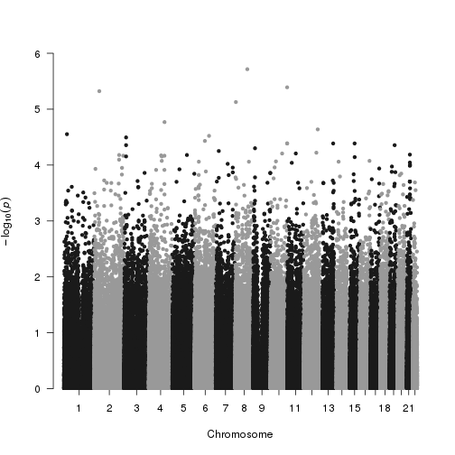

```r
plot(A1)
```

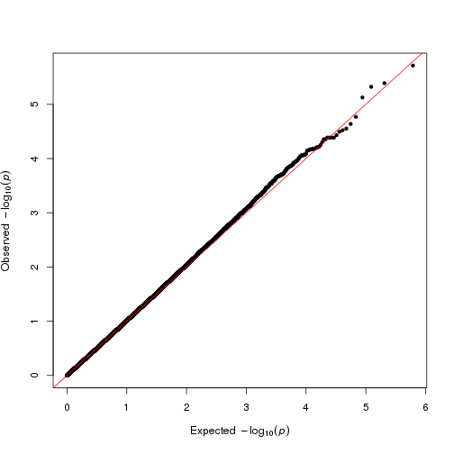

```r
plot(A1, "qq")
```

compare with [2]

- LNA: missing linkage and compare it with [2] since there are no significant SNPs in the GWAS to discuss on.

## FXI

```r
M2 <- solarPolygenic(tr_FXI ~ AGE, pdat, covtest=T)
```

```r
A2 <- solarAssoc(tr_FXI ~ AGE, pdat, genocov.files = gait1.snpfiles$genocov.files, snplists.files = gait1.snpfiles$snplists.files, snpmap.files = gait1.snpfiles$snpmap.files, cores = cores)
```

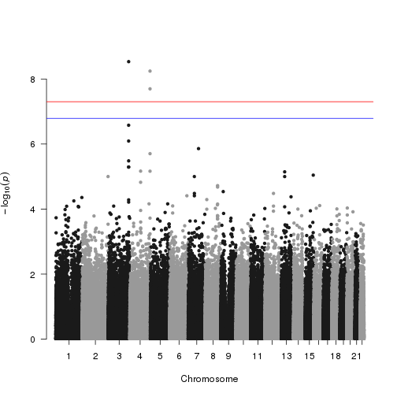

```r
plot(A2)
```

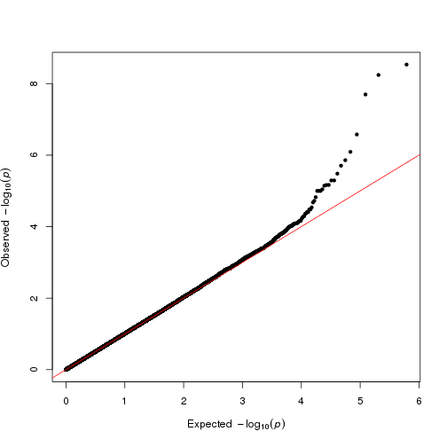

```r
plot(A2, "qq")
```

- LNA: falta linkage

### Throm

```r
M3 <- solarPolygenic(aff ~ AGE, pdat, covtest = TRUE)
M3
```

```
##
## Call: solarPolygenic(formula = aff ~ AGE, data = pdat, covtest = TRUE)
##
## File polygenic.out:
##  Pedigree:    dat.ped
##  Phenotypes:  dat.phe
##  Trait:       aff                   Individuals:  393
##
##           H2r is 0.5742941  p = 0.0043258  (Significant)
##         H2r Std. Error:  0.2183659
##
##            C2 is 0.1022669  p = 0.2401522  (Not Significant)
##          C2 Std. Error:  0.1470262      (C2 retained because nonzero)
##
##                                       AGE  p = 3.3186035e-14  (Significant)
##
##  No pedigrees shared households with other pedigrees
##
##  Kullback-Leibler R-squared is 0.1945195
##
##  Loglikelihoods and chi's are in aff/polygenic.logs.out
##  Best model is named housepoly and null0
##  Final models are named housepoly, house, poly, spor, nocovar
##  Initial sporadic and polygenic models are s0 and p0
##  Initial household and household polygenic models are h0 and hp0
##  Constrained covariate models are named no<covariate name>
```

```r
A3 <- solarAssoc(aff ~ AGE, pdat, genocov.files = gait1.snpfiles$genocov.files, snplists.files = gait1.snpfiles$snplists.files, snpmap.files = gait1.snpfiles$snpmap.files, cores = cores)
```

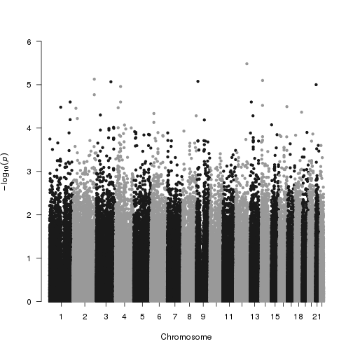

```r
plot(A3)
```

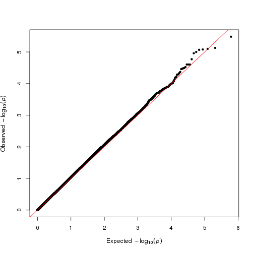

```r
plot(A3, "qq")
```

- LNA: falta linkage

## Refences

[1] JC Souto, L Almasy, M Borrell , F Blanco-Vaca, J Mateo, et al. Genetic susceptibility to thrombosis and its relationship to physiological risk factors: the GAIT study Genetic Analysis of Idiopathic Thrombophilia. American Journal of Human Genetics.2000; 67:1452–1459. [2] J.C. Souto, G.Pena, A. Ziyatdinov, A.Buil, S. López, J. Fontcuberta, J.M. Soria. A genomewide study of body mass index and its genetic correlation with thromboembolic risk. Thrombosis & Haemostasis. 2014;112(5):1036-43. [3] Maria Sabater-Lleal, Angel Martinez-Perez, Alfonso Buil, Lasse Folkersen, Juan Carlos Souto, Maria Bruzelius, Montserrat Borrell, Jacob Odeberg, Angela Silveira, Per Eriksson, Laura Almasy, Anders Hamsten, José Manuel Soria. A genome-wide association study identifies KNG1 as a genetic determinant of plasma factor XI Level and activated partial thromboplastin time.Arteriosclerosis, Thrombosis, and Vascular Biology. 2012; 32 (8): 2008-16.